# Introduction to R

```r
plot(mydata$height) # looks more like real data
```

[output not shown]

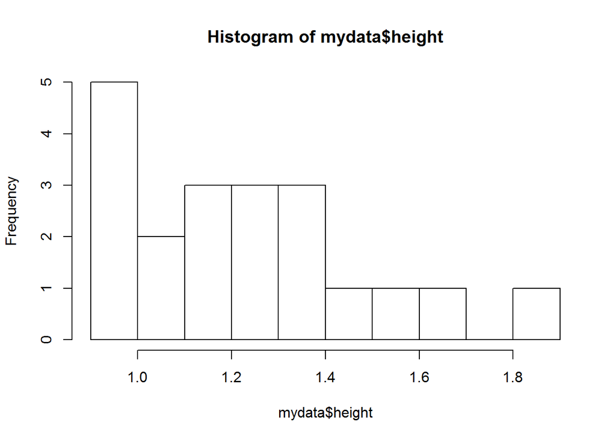

```r
hist(mydata$height, breaks = 10)
```

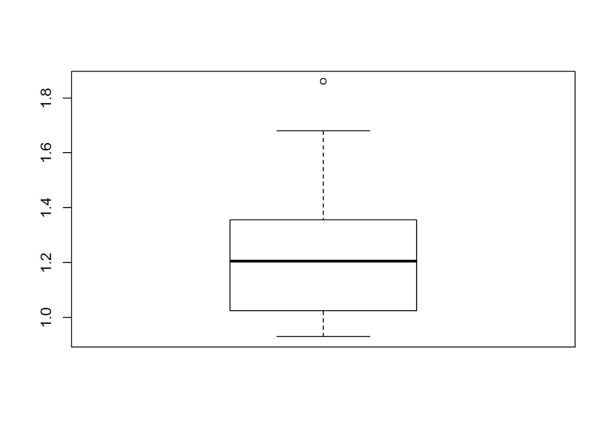

```r
boxplot(mydata$height)
```

You can also use this operation to apply functions to the variable e.g.

```r
sum(mydata$height) # cumulative heights
```

```
## [1] 24.64
```

```r
mean(mydata$age) # arithmetic mean of age
```

```
## [1] 30.5
```

```r
max(mydata$height) # maximum height in dataset
```

```
## [1] 1.86
```

You can use it to alter a variable

```r
# Change the type
typeof(mydata$age)
```

```
## [1] "double"
```

```r
mydata$age <- as.integer(mydata$age)
typeof(mydata$age)
```

```
## [1] "integer"
```

Realise that we are using ‘$’ to subset the dataframe i.e. isolate its component vectors. Vector subsetting, which allows you to access individual values, will be discussed in under the topic **Indexing**.

This operation can be used to also alter the values in a variable - after subsetting, just assign the desired values. This is the same thing as what we did with atomic vectors. R accepts the new object as the true values of the vector/column and all the old values are lost. Using the same principle, we can delete or add a column to the dataframe via the ‘assign’ key. When you are doing this, what you are telling R is that there is already vector in the dataframe that is either NULL or labeled by a certain name and that you are now assigning so-and-so values to it.

```r
mydata$height # note initial values
```

```
##  [1] 0.96 1.86 1.68 1.13 1.40 1.52 1.06 1.25 1.06 1.12 0.96 0.93 1.17 1.31
## [15] 1.48 0.99 1.31 1.24 1.25 0.96
```

```r
mydata$height <- round(rnorm(20, mean = 1.6, sd = .4), 2)
mydata$height # new values have been assigned
```

```
##  [1] 1.14 1.90 2.21 2.03 1.68 1.37 2.29 1.32 1.76 1.95 1.45 1.85 1.65 2.42
## [15] 1.23 1.67 1.93 1.31 0.94 1.26
```

```r
mydata$height <- NULL
mydata$height
```

```r
str(mydata) # column has been deleted unlike the case of an atomic vector.
```

```
## 'data.frame':    20 obs. of  4 variables:
##  $ key     : chr  "A" "B" "C" "D" ...
##  $ age     : int  21 22 23 24 25 26 27 28 29 30 ...
##  $ sex     : chr  "male" "female" "female" "male" ...
##  $ location: chr  "Abuja" "Abuja" "Abuja" "Abuja" ...
```

```r
dim(mydata) # dataframe has 4 columns
```

```
## [1] 20  4
```

```r
mydata$height <- round(rnorm(20, mean = 1.6, sd = .4), 2)
mydata$height # note completely new set of values; rnorm() performs random assortment
```

```
##  [1] 1.61 1.86 1.97 1.60 2.18 0.71 1.67 2.49 2.26 1.40 2.29 1.46 1.46 2.03
## [15] 1.28 1.91 2.34 2.08 1.43 1.95
```

```r
dim(mydata) # 5 columns
```

```
## [1] 20  5
```

Finally, let’s talk about the dimension names. In most dataframes, it is unnecessary and even impractical to name the rows. By default, data.frame() assigns integer values as row names. Column names are a must in R dataframes - if you create or import a dataframe that has unnamed variable, R will automatically assign names. You can try this out later when we start importing dataframes. Using colnames(), we can either determine the names of our variables or we can use it to edit existing names.

```r
colnames(mydata)
```

```
## [1] "key"      "age"      "sex"      "location" "height"
```

```r
colnames(mydata) <- c("primary key", "howold", "GENDER", "body_length")
colnames(mydata) # Oops! something went wrong. It is easy to miss out one of the variable and R won't even warn you! Not only did it create an 'NA' variable, it our variables have shifted and don't make sense.
```

```
## [1] "primary key" "howold"      "GENDER"      "body_length" NA
```

```r
anyNA(colnames(mydata)) # always do this to cross-check for 'NAs'
```

```
## [1] TRUE
```

```r
colnames(mydata) <- c("primary key", "howold", "GENDER", "town/city", "body_length") # problem fixed?
colnames(mydata)
```

```
## [1] "primary key" "howold"      "GENDER"      "town/city"   "body_length"
```

```r
anyNA(colnames(mydata)) # no missing value
```

```
## [1] FALSE
```

**Quiz:** Look carefully at these new variable names of *mydata*. Review in your mind the operations we have been carrying out, like subsetting the dataframe. Do you foresee any problems with using these column names? Think about it first and then try it out for yourself in the R console. What happened? Suggest ways to fix it and experiment again in the console.

**Answer:** Generally, it is best to use **‘oneword’** as variable names. R does not allow spacesor special characters in variable names, with the exception of “underscore” and “dot”. Thus, *mydata$body_length* and *mydata$body.length* are acceptable nomenclature in R. If for some reason you MUST circumvent this rule, you can enclose the name in back-ticks (` `) and R will accept the variable name the way it is.

```r
# This will work...
mydata$`primary key`
```

```
##  [1] "A" "B" "C" "D" "E" "F" "G" "H" "I" "J" "K" "L" "M" "N" "O" "P" "Q"
## [18] "R" "S" "T"
```

```r
mydata$`town/city`
```

```
##  [1] "Abuja"         "Abuja"         "Abuja"         "Abuja"
##  [5] "Lagos"         "Kaduna"        "Jos"           ""
##  [9] ""              "not known"     "not known"     "not known"
## [13] "Port Harcourt" "Maiduguri"     "Gombe"         "Lsgos"
## [17] "Makurdi"       "Sokoto"        "Akure"         "Minna"
```

# Importing Data

We have take a look at dataframes, which are probably the most ubiqitous data structures a worker or student would have to deal with (this should be an interesting hypothesis to test).

Even though we can create dataframes in R, most often you will be using datasets that were generated outside of R. In fairness to the work of other tech innovators, R cannot do everything and even if it could, some programs carry out certain tasks more efficiently than others. Thus, you will more likely find it easier to create a dataframe in spreadsheet programs like MS Excel or in relational database programmes such as MS Access or MySQL. Another good thing is that there are several R packages that allow us to import data from a variety of formats including statistical softward like SPSS, STATA and SAS. However, for the purpose of this introductory course, we will focus on more central themes and these you can use as a bridge to connect your R installation with any other program out there.

Before you proceed, kindly check what is in your workspace and then clear it if it’s not empty. If you can remember the code, refer to **Workspace**.

## Import from clipboard

Data can be imported using the clipboard. Visit this **link** to download a dataset in Excel format, select the range of cells for the entire table into R and copy them (for Windows use CTRL + C; OSX use CMD + C). Next open your R session and run the following code

```r
#extdata <- read.table("clipboard", header = TRUE, sep = "\t")
#head(extdata)

# For Mac users:
# extdata <- read.table(pipe("pbpaste"), header = TRUE, sep = "\t")
```

## Import from a text file

The file in this example is a .csv file (Comma Separated Values). This file can easily be generated from a spreadsheet or database application like MS Excel or MS Access, respectively. (In Excel, you save the open spreadsheet as .csv, while in Access, export your table to .CSV format). After you have acquired your text file, you can import it into R by running read.csv(). But before you proceed, please open the text file “*life_Nigeria_2000*” in Notepad (View the file in Windows Explorer, right click and select Open With…, then select Notepad)

```r
read.csv("life_Nigeria_2000.csv") # text file has been read but not yet in workspace
```

```
##        Sex Age.range Actual.population Actual.deaths     nMx     nqx
## 1     both      '<1'           4192910        533987 0.12735 0.11693
## 2     both     '1-4'          15490350        177422 0.01145 0.04459
## 3     both     '5-9'          16932250         52890 0.00312 0.01550
## 4     both   '10-14'          14684230         25585 0.00174 0.00867
## 5     both   '15-19'          12580990         31769 0.00253 0.01255
## 6     both   '20-24'          10371470         52087 0.00502 0.02480
## 7     both   '25-29'           8229800         61279 0.00745 0.03655
## 8     both   '30-34'           6625350         63204 0.00954 0.04659
## 9     both   '35-39'           5477010         57110 0.01043 0.05081
## 10    both   '40-44'           4611790         52686 0.01142 0.05553
## 11    both   '45-49'           3852130         50288 0.01305 0.06321
## 12    both   '50-54'           2929560         47651 0.01627 0.07815
## 13    both   '55-59'           2464620         54816 0.02224 0.10535
## 14    both   '60-64'           1947810         58147 0.02985 0.13890
```

[output cut: 119 more lines]

```r
imported_data <- read.csv("life_Nigeria_2000.csv") #study the default values
imported_data
```

```
##        Sex Age.range Actual.population Actual.deaths     nMx     nqx
## 1     both      '<1'           4192910        533987 0.12735 0.11693
## 2     both     '1-4'          15490350        177422 0.01145 0.04459
## 3     both     '5-9'          16932250         52890 0.00312 0.01550
## 4     both   '10-14'          14684230         25585 0.00174 0.00867
## 5     both   '15-19'          12580990         31769 0.00253 0.01255
## 6     both   '20-24'          10371470         52087 0.00502 0.02480
## 7     both   '25-29'           8229800         61279 0.00745 0.03655
## 8     both   '30-34'           6625350         63204 0.00954 0.04659
## 9     both   '35-39'           5477010         57110 0.01043 0.05081
## 10    both   '40-44'           4611790         52686 0.01142 0.05553
## 11    both   '45-49'           3852130         50288 0.01305 0.06321
## 12    both   '50-54'           2929560         47651 0.01627 0.07815
## 13    both   '55-59'           2464620         54816 0.02224 0.10535
## 14    both   '60-64'           1947810         58147 0.02985 0.13890
```

[output cut: 119 more lines]

```r
# You may view the dataset in a more readable form
View(imported_data)
```

Although .csv are the simplest and most commonly used formats for R and other data management applications, there are other functions for importing data for the more advanced user, which depend on the way the files were saved e.g. read.fwf (for Fixed Width Format files).

## Import from the Web

When you want to import data from the web, you will have to use the URL of the webpage. Many datasets that are available online, have been uploaded in the .csv format, for the very reasons stated earlier and you just need to copy and past the link and insert it as an argument in the function.

```r
#another_import <- read.csv("http://...")
#another_import
```

You may also import from search pages by entering the URL from the address bar - but make sure that it contains the search term.

```r
#yet_another <- readLines("http://www.ncbi.nlm.nih.gov/gds/?term=diabetes")
#head(yet_another) # use this function as the object may contain thousands of lines
```

## Other formats

You can read data from other formats into R, but these are usually found in various R packages that are available on CRAN or Github. We will not try to use them at this stage but you are free to explore these on your own.

# Indexing

This is a crucial part of handling R objects and with this topic, you are now delving into data operations proper. Indexing allows you to identify discrete points in the the data set as well as making important manipulations such as data cleaning. Indexing applies to all R objects and we will now look at this more closely. The basic operator R uses for indexing is the hard bracket `[]`.

## Vectors

Just like much of R, the principles of indexing find their basis in atomic vectors, and we will dwell on this extensively in this section, as what you learn here will can be applied to the other data structures.

```r
a <- c(5, 6, 8, 2, 0, 9, 1, 7)
a
```

```
## [1] 5 6 8 2 0 9 1 7
```

```r
a[4] # 4th element in vector a
```

```
## [1] 2
```

```r
# also works for other types of atomic vectors
b <- c("Tom", "Dick", "Harry", "Sally", "Alice", "Mary")
b
```

```
## [1] "Tom"   "Dick"  "Harry" "Sally" "Alice" "Mary"
```

```r
b[6] # 6th element in the vector
```

```
## [1] "Mary"
```

```r
c <- c(FALSE, FALSE, TRUE, TRUE, FALSE, F, F, T, T, T, F, T) # note that we can use 'TRUE/FALSE' and 'T/F' interchangeably
c
```

```
##  [1] FALSE FALSE  TRUE  TRUE FALSE FALSE FALSE  TRUE  TRUE  TRUE FALSE
## [12]  TRUE
```

```r
c[2]
```

```
## [1] FALSE
```

Notice (again) that when you print out the object in the console, there is that number [1] on the left hand side and if your vector is wrapped into the next row, you will see another number in the hard brackets. This number is the ‘index’ and it always counts from number 1 from left to right.

We can also use negative indexing - this works for numerical (integer and double) vectors.

```r
a[-4]
```

```
## [1] 5 6 8 0 9 1 7
```

Indexing can be done over multiple points or for a range of points in the vector:

```r
a[c(1, 2, 3)]
```

```
## [1] 5 6 8
```

```r
b[c(2, 4, 6)]
```

```
## [1] "Dick"  "Sally" "Mary"
```

```r
a[c(4:6)]
```

```
## [1] 2 0 9
```

```r
b[c(2:4, 6)]
```

```
## [1] "Dick"  "Harry" "Sally" "Mary"
```

Quiz: Try runnning this code `a[1, 2, 3]`. What happened? can you explain it? (Tip: Look at the section **Dataframes**)

This kind of indexing is very useful when you can keep track of the indices with your eyes. However, as the size and complexity of the data structure increases, this becomes impractical and we have to resort to other ways of identifying our values.

The code we just ran identified particular elements in the vector by their indices i.e. their position within the vector. We can also use boolean operators to carry out indexing using the **values** themselves.

```r
a; a[a == 2]
```

```
## [1] 5 6 8 2 0 9 1 7
```

```
## [1] 2
```

```r
b; b[b == "Mary"]
```

```
## [1] "Tom"   "Dick"  "Harry" "Sally" "Alice" "Mary"
```

```
## [1] "Mary"
```

```r
c; c[c == FALSE]
```

```
##  [1] FALSE FALSE  TRUE  TRUE FALSE FALSE FALSE  TRUE  TRUE  TRUE FALSE
## [12]  TRUE
```

```
## [1] FALSE FALSE FALSE FALSE FALSE FALSE
```

This operation is very important in practical terms. Now, consider this vector

```r
# create a vector that contains a random sample of size 1000, with replacement, from a population of 10 million values with a population mean of 45.344 and standard deviation 6.74 (values rounded to the first decimal)
my_sample <- round(sample(rnorm(1e7, 45.344, 6.74), size = 1e3, replace = TRUE), 1)
my_sample
```

```
##    [1] 41.5 46.8 39.8 47.0 57.3 52.2 52.5 51.6 39.2 40.4 48.4 35.5 51.3
##   [14] 37.8 50.5 49.8 37.3 44.5 36.0 35.3 55.1 45.5 54.5 56.9 52.5 46.8
##   [27] 41.5 33.7 34.6 43.8 46.9 43.8 57.7 42.0 44.4 52.5 39.7 56.7 41.8
##   [40] 44.9 44.1 43.9 55.4 47.6 40.1 48.9 37.1 45.6 50.8 44.1 47.2 47.7
##   [53] 48.9 43.3 52.9 41.6 48.6 42.3 33.0 53.5 59.3 59.4 51.7 45.8 49.8
##   [66] 54.5 43.8 48.7 35.3 51.9 36.9 39.1 39.5 47.1 49.1 34.9 41.5 51.0
##   [79] 34.4 36.6 41.6 43.7 52.0 48.3 45.8 40.4 43.7 38.2 53.5 40.5 41.3
##   [92] 37.7 26.5 31.6 49.9 60.0 53.5 44.2 46.2 55.0 37.7 45.1 43.5 37.1
##  [105] 44.0 48.6 44.1 49.2 47.6 43.3 51.4 51.2 40.5 45.7 35.1 44.7 60.2
##  [118] 51.7 44.0 45.5 52.9 51.7 49.0 46.6 50.5 50.6 45.8 51.7 42.5 41.3
##  [131] 45.0 52.6 45.5 44.3 43.7 48.1 52.0 34.7 48.8 44.2 36.8 34.9 46.7
##  [144] 55.0 35.1 45.1 35.0 44.8 47.5 48.8 40.7 47.0 49.8 45.1 44.5 43.2
##  [157] 39.9 53.5 48.0 45.0 54.1 37.5 41.1 43.6 35.3 43.6 43.7 54.1 41.6
##  [170] 48.7 46.0 39.9 47.8 33.8 33.9 48.9 46.9 41.8 44.0 35.8 50.4 41.2
##  [183] 45.8 49.7 38.8 28.8 35.0 39.1 48.4 42.4 32.4 43.7 55.1 55.4 46.9
```

[output cut: 62 more lines]

What if we wanted to identify the particular values are equal to 42.9?

```r
# extract the values in  my_sample that are equal to 42.9
my_sample[my_sample == 42.9]
```

```
## [1] 42.9 42.9 42.9 42.9
```

At this point I will introduce the boolean (logical) operators because they are very useful in indexing. See the table below

Now let’s use these operators to carry out indexing. Also feel free to experiment with these operators

```r
a[a == 7]
```

```
## [1] 7
```

```r
b[b != "Sally"]
```

```
## [1] "Tom"   "Dick"  "Harry" "Alice" "Mary"
```

```r
a[a < 5]
```

```
## [1] 2 0 1
```

```r
a[a >=5]
```

```
## [1] 5 6 8 9 7
```

```r
c[c == TRUE]
```

```
## [1] TRUE TRUE TRUE TRUE TRUE TRUE
```

Quiz: Try these two lines of code and discuss the output.

```r
c[c < TRUE]
```

```
## [1] FALSE FALSE FALSE FALSE FALSE FALSE
```

```r
c[c > TRUE]
```

```
## logical(0)
```

Indexing is extremely useful for manipulating the elements of a vector and to accomplish this in R, we use the assignment `<-` operator. In essence, you “pick on” an index position in a vector and assign a new value to it.

```r
a[2]
```

```
## [1] 6
```

```r
a[2] <- 99
a[2]
```

```
## [1] 99
```

```r
a
```

```
## [1]  5 99  8  2  0  9  1  7
```

```r
# you can do it in multiples
a[c(3:5)] <- 100 # the value 100 is assigned to positions 3 through 5 in vector "a"
a
```

```
## [1]   5  99 100 100 100   9   1   7
```

Quiz; After entering data on names of subjects into vector b, you suddenly realize that Sally and Dick were not actually part of the dataset, and you want to replace with Robert and Michelle. Use the indexing and assignment operations to correct the error and print out the result to the R console.

## Matrices

Indexing applies to matrices and we also use the same operator, `[]`. However, because there are two dimensions in a matrix, there are 2 reference points that apply to each value in the object - rows and columns. Thus, when you apply the hard bracket, you should be able to map it to these two dimensions. This is accomplished by dividing the content of the operator into 2 spaces - one for row and the other for column viz `[<row>, <column>]`. This is apparent from a basic matrix on printing it out in the console.

```r
matrix(1:12, nrow = 3)
```

```
##      [,1] [,2] [,3] [,4]
## [1,]    1    4    7   10
## [2,]    2    5    8   11
## [3,]    3    6    9   12
```

```r
leap_year <- seq(from = 1700, by = 4, length.out = 200)
my_mat <- matrix(leap_year,
                 ncol = 10,
                 byrow = TRUE,
                 dimnames = list(decade = c("I", "II", "III", "IV", "V", "VI", "VII", "VIII", "IX", "X", "XI", "XII", "XIII", "XIV", "XV", "XVI", "XVII", "XVIII", "XIX", "XX"), year = c("one", "two", "three", "four", "five", "six", "seven", "eight", "nine", "ten"))) # creating a matrix with named dimensions
head(my_mat)
```

```
##       year
## decade  one  two three four five  six seven eight nine  ten
##    I   1700 1704  1708 1712 1716 1720  1724  1728 1732 1736
##    II  1740 1744  1748 1752 1756 1760  1764  1768 1772 1776
##    III 1780 1784  1788 1792 1796 1800  1804  1808 1812 1816
##    IV  1820 1824  1828 1832 1836 1840  1844  1848 1852 1856
##    V   1860 1864  1868 1872 1876 1880  1884  1888 1892 1896
##    VI  1900 1904  1908 1912 1916 1920  1924  1928 1932 1936
```

```r
my_mat[7, 4] # The 4th year in the 7th decade is
```

```
## [1] 1952
```

```r
my_mat[c(3:7), c(5, 6)] # submatrix containing years 5 & 6 of the 3rd to 7th decades
```

```
##       year
## decade five  six
##    III 1796 1800
##    IV  1836 1840
##    V   1876 1880
##    VI  1916 1920
##    VII 1956 1960
```

We have a named matrix *my_mat*, and we can carry out indexing using the names as reference points instead just the numbered indices. This helps a lot when dealing with very large matrices - rows/columns can come in the thousands, if not millions. You can simply call them by name!

```r
my_mat[decade = "IV", year = "five"]
```

```
## [1] 1836
```

```r
my_mat["IV", "five"] # same thing
```

```
## [1] 1836
```

```r
# select a range of cells
nineteen_century <- my_mat[c("III", "IV", "V"), c("six", "seven", "eight", "nine", "ten")]
nineteen_century
```

```
##       year
## decade  six seven eight nine  ten
##    III 1800  1804  1808 1812 1816
##    IV  1840  1844  1848 1852 1856
##    V   1880  1884  1888 1892 1896
```

Finally, indexing can be used to assign new values to a matrix and boolean operators work here as well.

```r
# Indexing a character matrix
b <- c("Tom", "Dick", "Harry", "Sally", "Alice", "Mary")
char_matrix <- matrix(b, nrow = 3)
char_matrix
```

```
##      [,1]    [,2]
## [1,] "Tom"   "Sally"
## [2,] "Dick"  "Alice"
## [3,] "Harry" "Mary"
```

```r
char_matrix[3, 2] <- "Maxwell" # assign a new value
char_matrix
```

```
##      [,1]    [,2]
## [1,] "Tom"   "Sally"
## [2,] "Dick"  "Alice"
## [3,] "Harry" "Maxwell"
```

```r
# Using boolean operators
char_matrix[char_matrix == "Maxwell"] <- "Mary"
char_matrix
```

```
##      [,1]    [,2]
## [1,] "Tom"   "Sally"
## [2,] "Dick"  "Alice"
## [3,] "Harry" "Mary"
```

```r
char_matrix[char_matrix == "Tom" | char_matrix == "Alice"] <- "Siblings"
char_matrix
```

```
##      [,1]       [,2]
## [1,] "Siblings" "Sally"
## [2,] "Dick"     "Siblings"
## [3,] "Harry"    "Mary"
```

## Dataframes

To index dataframes, R uses a combination of the operations applicable to vectors and matrices.

```r
# load data
my_data <- read.csv("life_Nigeria_2000.csv", header = TRUE, stringsAsFactors = TRUE, na.strings = "")
dim(my_data)
```

```
## [1] 66 11
```

```r
head(my_data)
```

```
##    Sex Age.range Actual.population Actual.deaths     nMx     nqx     lx
## 1 both      '<1'           4192910        533987 0.12735 0.11693 100000
## 2 both     '1-4'          15490350        177422 0.01145 0.04459  88307
## 3 both     '5-9'          16932250         52890 0.00312 0.01550  84369
## 4 both   '10-14'          14684230         25585 0.00174 0.00867  83062
## 5 both   '15-19'          12580990         31769 0.00253 0.01255  82341
## 6 both   '20-24'          10371470         52087 0.00502 0.02480  81308
##     ndx    nLx      Tx   ex
## 1 11693  91815 5161945 51.6
## 2  3938 343778 5070130 57.4
## 3  1307 418578 4726352 56.0
## 4   720 413508 4307774 51.9
## 5  1033 409124 3894265 47.3
## 6  2016 401501 3485141 42.9
```

```r
str(my_data)
```

```
## 'data.frame':    66 obs. of  11 variables:
##  $ Sex              : Factor w/ 3 levels "both","females",..: 1 1 1 1 1 1 1 1 1 1 ...
##  $ Age.range        : Factor w/ 22 levels "'<1'","'1-4'",..: 1 2 12 3 5 6 7 8 9 10 ...
##  $ Actual.population: int  4192910 15490350 16932250 14684230 12580990 10371470 8229800 6625350 5477010 4611790 ...
##  $ Actual.deaths    : int  533987 177422 52890 25585 31769 52087 61279 63204 57110 52686 ...
##  $ nMx              : num  0.12735 0.01145 0.00312 0.00174 0.00253 ...
##  $ nqx              : num  0.11693 0.04459 0.0155 0.00867 0.01255 ...
##  $ lx               : int  100000 88307 84369 83062 82341 81308 79292 76394 72835 69134 ...
##  $ ndx              : int  11693 3938 1307 720 1033 2016 2898 3559 3701 3839 ...
##  $ nLx              : int  91815 343778 418578 413508 409124 401501 389215 373072 354922 336072 ...
##  $ Tx               : int  5161945 5070130 4726352 4307774 3894265 3485141 3083640 2694426 2321354 1966432 ...
##  $ ex               : num  51.6 57.4 56 51.9 47.3 42.9 38.9 35.3 31.9 28.4 ...
```

```r
colnames(my_data)
```

```
##  [1] "Sex"               "Age.range"         "Actual.population"
##  [4] "Actual.deaths"     "nMx"               "nqx"
##  [7] "lx"                "ndx"               "nLx"
## [10] "Tx"                "ex"
```

```r
my_data[2]
```

```
##    Age.range
## 1       '<1'
## 2      '1-4'
## 3      '5-9'
## 4    '10-14'
## 5    '15-19'
## 6    '20-24'
## 7    '25-29'
## 8    '30-34'
## 9    '35-39'
## 10   '40-44'
## 11   '45-49'
## 12   '50-54'
## 13   '55-59'
## 14   '60-64'
```

[output cut: 52 more lines]

```r
my_data[[2]]
```

```
##  [1] '<1'    '1-4'   '5-9'   '10-14' '15-19' '20-24' '25-29' '30-34'
##  [9] '35-39' '40-44' '45-49' '50-54' '55-59' '60-64' '65-69' '70-74'
## [17] '75-79' '80-84' '85-89' '90-94' '95-99' '100+'  '<1'    '1-4'
## [25] '5-9'   '10-14' '15-19' '20-24' '25-29' '30-34' '35-39' '40-44'
## [33] '45-49' '50-54' '55-59' '60-64' '65-69' '70-74' '75-79' '80-84'
## [41] '85-89' '90-94' '95-99' '100+'  '<1'    '1-4'   '5-9'   '10-14'
## [49] '15-19' '20-24' '25-29' '30-34' '35-39' '40-44' '45-49' '50-54'
## [57] '55-59' '60-64' '65-69' '70-74' '75-79' '80-84' '85-89' '90-94'
## [65] '95-99' '100+'
## 22 Levels: '<1' '1-4' '10-14' '100+' '15-19' '20-24' '25-29' ... '95-99'
```

```r
is.factor(my_data[[2]])
```

```
## [1] TRUE
```

```r
my_data[5, 9]
```

```
## [1] 409124
```

```r
my_data$Actual.deaths[6]
```

```
## [1] 52087
```

```r
my_data[8, "Actual.deaths"]
```

```
## [1] 63204
```

```r
my_data[my_data$Sex == 'both', ]
```

```
##     Sex Age.range Actual.population Actual.deaths     nMx     nqx     lx
## 1  both      '<1'           4192910        533987 0.12735 0.11693 100000
## 2  both     '1-4'          15490350        177422 0.01145 0.04459  88307
## 3  both     '5-9'          16932250         52890 0.00312 0.01550  84369
## 4  both   '10-14'          14684230         25585 0.00174 0.00867  83062
## 5  both   '15-19'          12580990         31769 0.00253 0.01255  82341
## 6  both   '20-24'          10371470         52087 0.00502 0.02480  81308
## 7  both   '25-29'           8229800         61279 0.00745 0.03655  79292
## 8  both   '30-34'           6625350         63204 0.00954 0.04659  76394
## 9  both   '35-39'           5477010         57110 0.01043 0.05081  72835
## 10 both   '40-44'           4611790         52686 0.01142 0.05553  69134
## 11 both   '45-49'           3852130         50288 0.01305 0.06321  65295
## 12 both   '50-54'           2929560         47651 0.01627 0.07815  61167
## 13 both   '55-59'           2464620         54816 0.02224 0.10535  56387
## 14 both   '60-64'           1947810         58147 0.02985 0.13890  50447
```

[output cut: 31 more lines]

```r
my_data[my_data$Actual.deaths < 10000, ]
```

```
##        Sex Age.range Actual.population Actual.deaths     nMx     nqx   lx
## 20    both   '90-94'             16380          5204 0.31768 0.81330 1769
## 21    both   '95-99'              1740           757 0.43531 0.86249  330
## 22    both    '100+'               100            58 0.58128 1.00000   45
## 41   males   '85-89'             35650          8591 0.24097 0.75189 4911
## 42   males   '90-94'              5970          2012 0.33698 0.83787 1218
## 43   males   '95-99'               510           234 0.45788 0.87966  198
## 44   males    '100+'                20            12 0.60362 1.00000   24
## 64 females   '90-94'             10410          3192 0.30661 0.79854 2382
## 65 females   '95-99'              1230           524 0.42596 0.85504  480
## 66 females    '100+'                80            46 0.57569 1.00000   70
##     ndx   nLx    Tx  ex
## 20 1439  4528  5261 3.0
## 21  285   654   732 2.2
## 22   45    78    78 1.7
## 41 3692 15323 18772 3.8
## 42 1021  3029  3448 2.8
## 43  174   380   419 2.1
## 44   24    39    39 1.7
## 64 1902  6203  7288 3.1
## 65  410   963  1084 2.3
## 66   70   121   121 1.7
```

# R Graphics

## Using basic graphs

One of the major strengths of R is data visualization for exploratory data analysis and for communicating the story of your data to various classes of audiences. A basic R installation comes with powerful graphics capabilities and there are also packages that have been developed to extend this to phenomenal limits. Without gainsaying, this is where R really shines.

In this training manual, the focus will be on the basic graphics functions which will be sufficient for most of the visualizations one would want to create within the workplace or even at school. The student is encouraged to take a look at packages like ggplot2, ggvis, ggtree, lattice, etc., and learn to use them as he/she advances in the art of plotting with R.

It is difficult to discuss data visualization without explicitly discussing statistical methods, which is beyond the scope of this manual. Attempt will however be made to establish the linkage between the two.

## Some basics of R plots

The plots that will be treated are principally the basic types that are used in exploring and presenting data. They are: - The bar chart - The histogram - The Box-and-Whiskers plot - The Scatterplot

**Some supportive knowledge** Aside from plotting charts, data can be summarised, presented and communicated in other formats, notably tables. Also, when we are trying to create certain visualizations, it may be necessary to summarize the data in this format and passing the resulting output as an argument to a function that generates a plot. In R, to tabulate data, we use the `table()` function.

```r
# Loading our mock dataset
mydata <- read.csv("mockdata.csv")
# obtain a frequency count for sex
head(mydata)
```

```
##   X key age    sex height location
## 1 1   A  21   male   0.96    Abuja
## 2 2   B  22 female   1.86    Abuja
## 3 3   C  23 female   1.68    Abuja
## 4 4   D  24   male   1.13    Abuja
## 5 5   E  25 female   1.40    Lagos
## 6 6   F  26 female   1.52   Kaduna
```

```r
sex <- mydata$sex
table(sex)
```

```
## sex
##        female   male
##      2     11      7
```

```r
# Some data cleaning...
as.character(mydata$sex); mydata$sex[mydata$sex == ""] <- "female"
```

```
##  [1] "male"   "female" "female" "male"   "female" "female" "female"
##  [8] "male"   "male"   "male"   "female" "female" ""       "female"
## [15] ""       "male"   "female" "male"   "female" "female"
```

```r
mydata$sex <- factor(mydata$sex)
table(mydata$sex)
```

```
##
## female   male
##     13      7
```

```r
# can crosstabulate two variables
table(mydata$location, mydata$sex) # notice problems caused by typo!
```

```
##
##                 female male
##                      0    2
##   Abuja              2    2
##   Akure              1    0
##   Gombe              1    0
##   Jos                1    0
##   Kaduna             1    0
##   Lagos              1    0
##   Lsgos              0    1
##   Maiduguri          1    0
##   Makurdi            1    0
##   Minna              1    0
##   not known          2    1
##   Port Harcourt      1    0
##   Sokoto             0    1
```

```r
# can also crosstabulate across multiple variables using xtabs()
```

Often, the data are summarised in terms of proportions rather than counts - and to do this, R has the `prop.table()` and this function uses the table rather than the object as its main argument

```r
prop.table(table(mydata$sex))
```

```
##
## female   male
##   0.65   0.35
```

When trying to visualize your data, one quick thing that can be done is to call plot(), which is a function that quickly draws a chart of the whole or parts of the dataset, depending on how you call it.

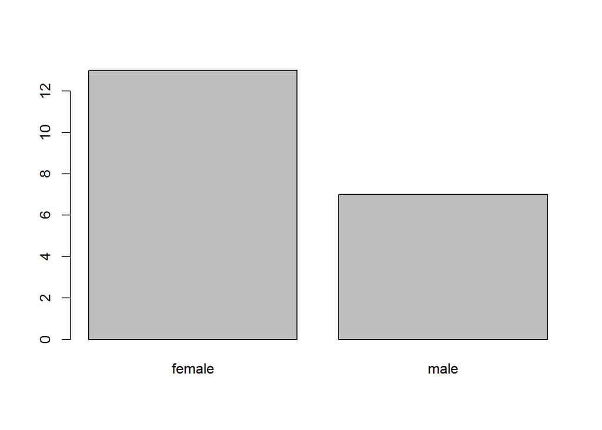

```r
# plot(mydata) plots as many variables as are available
plot(mydata$sex)
```

```r
plot(mydata$height)
```

[output not shown]

```r
# note the kinds of plots rendered based on level of measurement of the variable
```

**The Bar Chart** The bar chart is usually built with categorical variable, which, in R, are represented by factors, with levels representing the corresponding categories.

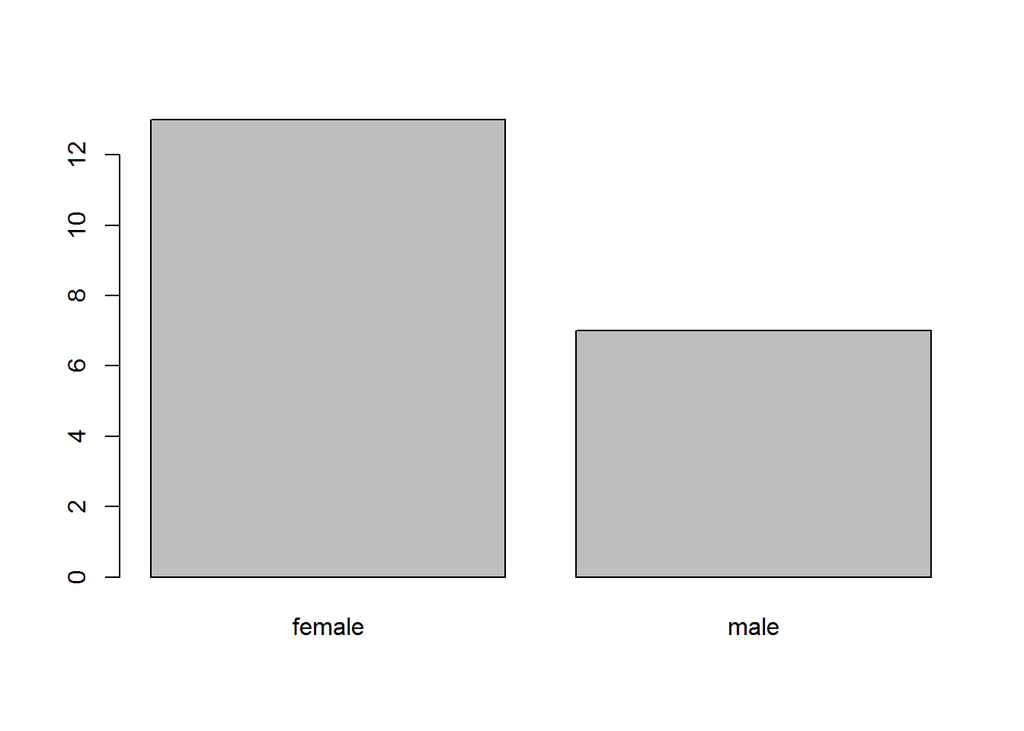

```r
barplot(table(mydata$sex))
```

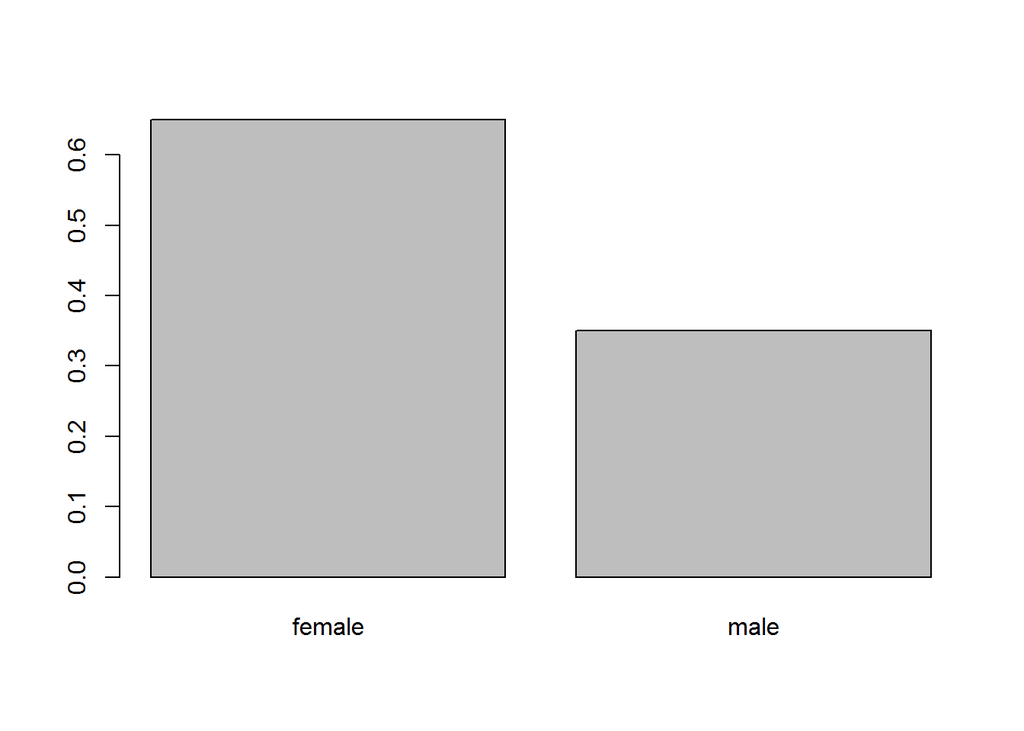

```r
barplot(prop.table(table(mydata$sex)))
```

**The Histogram** The histogram is looks like the barchart but is used to plot numerical vectors

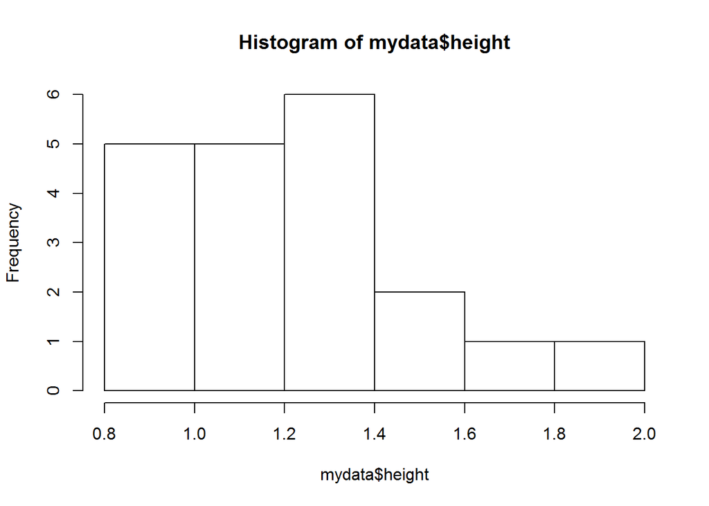

```r
hist(mydata$height)
```

**The Box-and-Whiskers Plot** Also simply known as the box plot, this chart is useful for displaying numerical data distributions that are skewed. Detailed discussions on interpretation and uses of box plots are beyond the scope of this course.

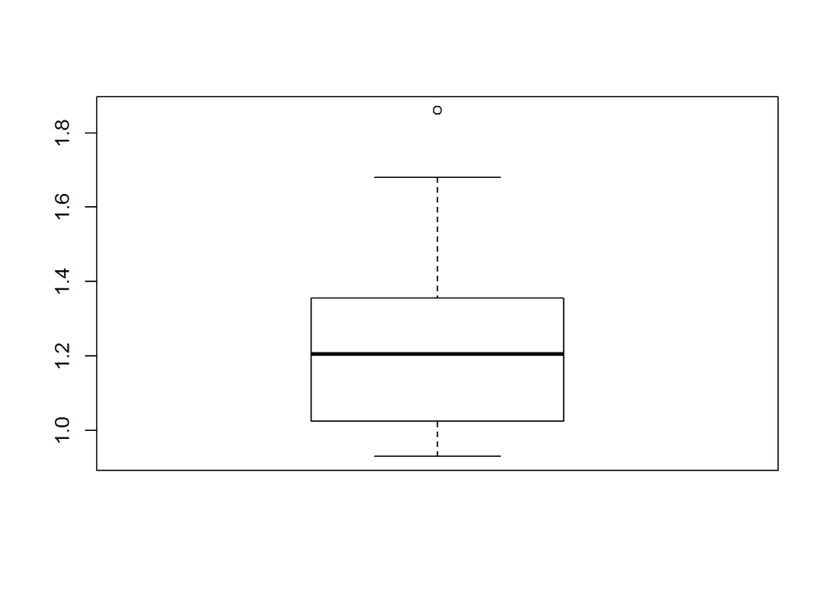

```r
boxplot(mydata$height)
```

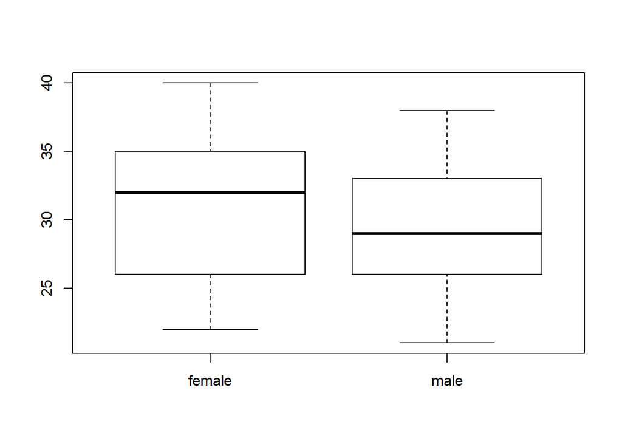

```r
boxplot(mydata$age ~ mydata$sex)
```

**The Scatterplot** The scatterplot is great for displaying numerical data that is measured on the ratio scale (a term that essentially means that zero and multiple values are meaningful) and can be used for univariate and multivariate analyses. Lines can be fitted to this plot for the purpose of carrying out regression. (Of course, being a statistical program, R can compute regression and correlation coefficients - again, beyond this level of study, but important enough to warrant further study by novices).

```r
plot(mydata$height)
```

[output not shown]

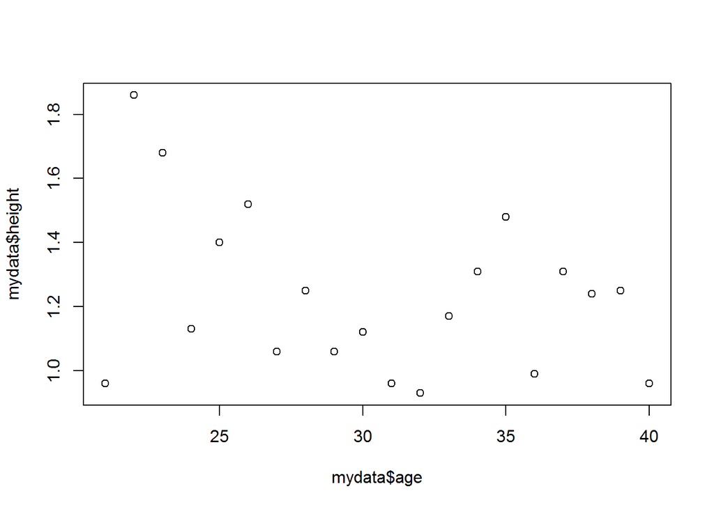

```r
plot(mydata$age, mydata$height)
```